The purpose of this report is to begin to dive into how each of the career statistics relate to one another. Focusing first across all weightclasses, some general insights may be found before specifically looking at the career statistics in individual weightclasses.

#### LOADING ALL PACKAGES AND LIBRARIES

```r
options(scipen=999) #stopping scientific notation

#Check is the packages are already installed and load the library
pkgTest <- function(...) {
  pkg <- list(...)
  for (i in 1:length(pkg)) {
    if (!require(pkg[[i]], character.only = TRUE)) {
      install.packages(pkg[[i]], dep = TRUE)
      if(!require(pkg[[i]], character.only = TRUE)) stop("Package not found")
    }
  }
}



pkgTest("esquisse")
pkgTest("randomForest")
pkgTest("psych")
pkgTest("corrplot")
pkgTest("ggplot2")
pkgTest("rvest")
pkgTest("dplyr")
pkgTest("tidyr")
pkgTest("stringr")
pkgTest("dplyr")
pkgTest("tidyr")
pkgTest("purrr")
pkgTest("data.table")
pkgTest("openxlsx")
pkgTest("here")


path = "C:/Users/rjobrien/Desktop/Personal Projects/UFC/"
```

#### LOADING IN DATA

```r
careers_stats = read.xlsx(paste0(path, "Data Sources/1-UFC Fighter Career Summary Stats.xlsx"))
```

#### CORRELATIONS - CORRELATIONS ACROSS ALL WEIGHTCLASSES

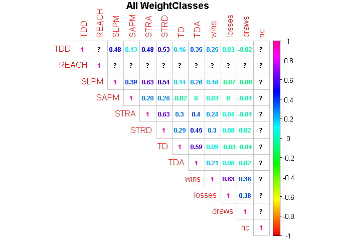

```r
#======================================#
#CORRELATION PLOT
#======================================#
#Buiding a dataframe with the correlations
cor_career_stats = cor(careers_stats[, c(3, 6:16)])

#Plotting the correlations
col1 <-rainbow(100, s = 1, v = 1, start = 0, end = 0.9, alpha = 1)
corrplot(cor_career_stats,
         col = col1,
         type = "upper",
         method = "number",
         number.cex = 0.75,
         title = "All WeightClasses",
         mar=c(0,0,1,0))
```

## Results

- A strong positive relationship exists between wins and losses.
- Losses are not related to anything apart from wins
- Draws are not related to anything apart from wins and losses
- A small positive relation exists between Wins and takedown accuracy, striking accuracy, and takedown defence
- Positive relationships exist between takedown accuracy and stra, tdd, td, slpm
- Small positive relationships exist between takedowns and stra, strd
- Moderate positive relationships exist between strd and tdd, slpm, stra.
- A small positive relationship also exists between strd and sapm.
- A moderate positive relationships exist between slpm and tdd
- A moderate positive relationships exist between sapm and slpm
- A moderate positive relationships exist between stra and tdd, slpm.
- A small positive relationship also exists between stra and sapm.

## Interpretation

- Wins and losses are presumably positively related because the more wins you have the more losses you are of likely to have as well.
- No fight statistic (e.g., stra) appears to be related to losing in general
- Ttakedown accuracy, striking accuracy, and takedown defence might influence the likelihood of winning, such that if you’re more skilled in these areas you are more likely to have won
- High takedown accuracy might be based on your ability to defend takedowns and strike effectively to set up your own takedowns
- Setting up takedowns usually requires striking, and the ability to defend against your opponents strikes to remain standing
- MAYBE Higher striking defence means you’re likely engaging in a striking battle with your opponent
- If your takedown defense is good it means you’re probably spending more time striking
- The more you attempt to strike the more likely you are to land per minute
- The striking accuracy may increase as you defend more takedowns and gain confidence, leading to you landing more per minute
- Thos who have higher accuracy in striking might attempt more strikes because their confidence is higher

#### CORRELATIONS - CORRELATIONS BY WEIGHTCLASS

The correlation plots by weightclass won’t be examined for now. The general asummption is that most weightclasses will be similar to the “all weightclasses” correlation plot. The more mature weightclasses may be more representative compared to the younger weightclasses.

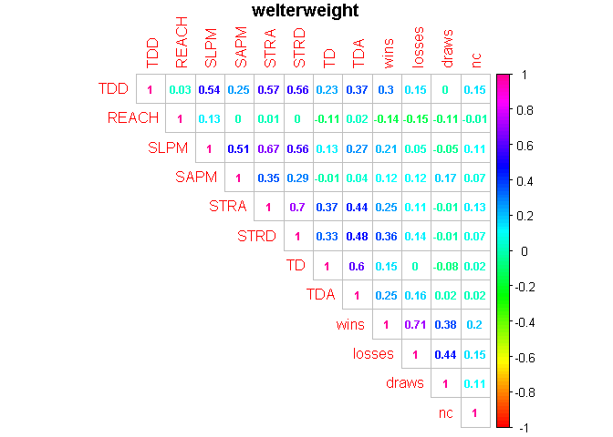

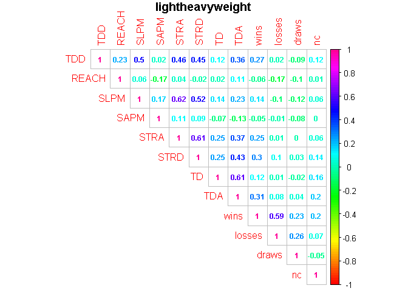

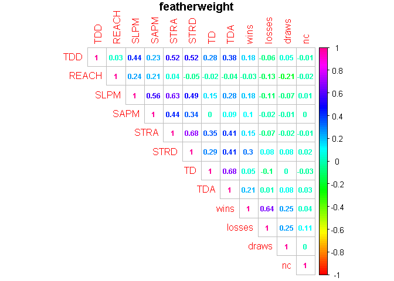

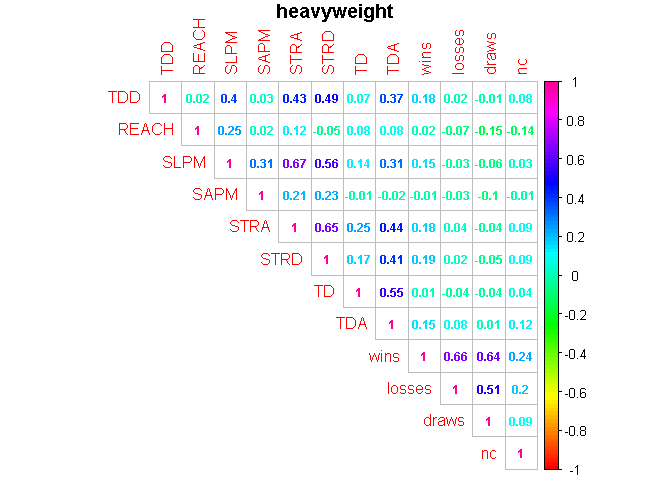

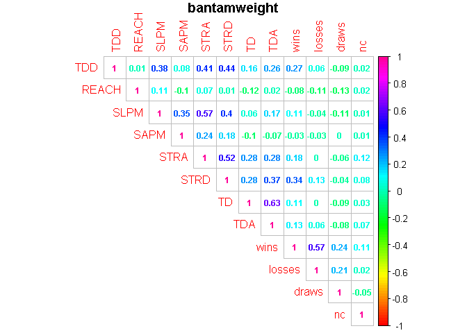

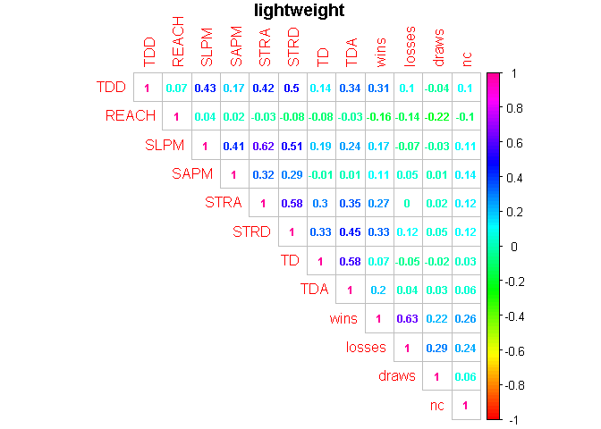

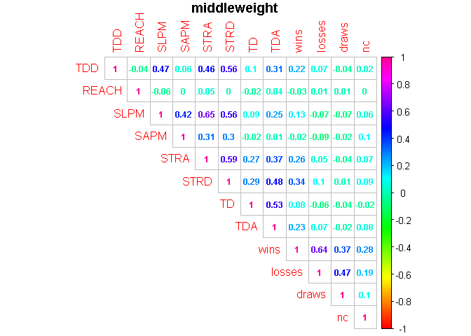

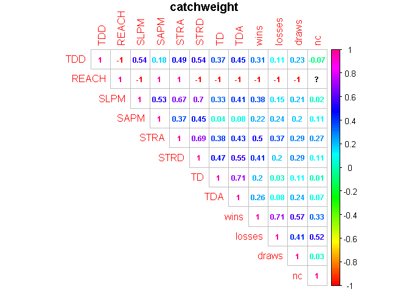

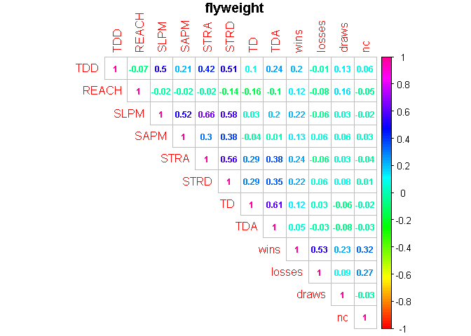

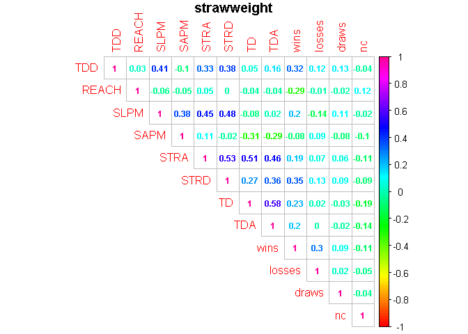

```r
count = 1

for (w in na.omit(unique(careers_stats$WeightClass))){

  #Subset the data
  temp = subset(careers_stats, WeightClass == w)


  #======================================#
  #PLOTTING THE CORRELATION MATRIX - CLEAN UP!
  #======================================#
  #Plotting the correlations
  col1 <-rainbow(100, s = 1, v = 1, start = 0, end = 0.9, alpha = 1)


  corrplot(cor(temp[, c(3, 6:16)], use = "pairwise.complete.obs"),
           method = "number",
           number.cex = 0.75,
           type = 'upper',
           col = col1,
           title = w,
           mar=c(0,0,1,0))


  #Make a dataframe containing all of the relevant correlations for the weightclass
  temp2 = temp %>%
            do(as.data.frame(cor(temp[, c(3, 6:16)], use = "pairwise.complete.obs")))


  #Combine all weightclasses correlation data together
  temp2$WeightClass = w

  if(count == 1){
    cor_careers_stats = temp2
  }else{
    cor_careers_stats = rbind(temp2, cor_careers_stats)
  }

  count = count + 1

}
```

```r
#Rounding the value to two digits
cor_careers_stats[,1:12] = lapply(cor_careers_stats[,1:12], function(x) round(x, 2))
```